# Capstone Project Data Wrangling v1

H Karen Tam

October 26, 2017

# Apply Data Wrangling to Capstone Project

## 1. Add your cleaned-up data set to the github repository for your project.

My cleaned up csv file:

https://github.com/karentam/capstoneproject1/blob/master/income_life_spend_cancer_full_join.csv

## 2. Summarize the most important steps you took in cleaning up your data in a short document.

### Reshape the data for making plots and descriptive statistics

I use gather() in tidyr package to gather year columns into key-value pairs. The restructured data frame is easier to do scatter plots, histograms, and descriptive statistics based on countries and years.

### Join the data from different data frames

I use full_join () and inner_join() in dplyr package to join all variables together into a data frame. I also obtain total numbers of lung, liver, and stomach cancer deaths for each country in different years by adding numbers of male and female, and enter these numbers into the data frame. It is easier to make scatter plots and show relationships between income and life expectancy, life expectancy and health spending, as well as life expectancy and various cancer deaths.

### Examine Outliers

I run summary statistics, make histograms and subsets to identify outliers for each variable. Outliers are examined and are reasonable with the countries’ situations in specific years. For example, very short life expectancy numbers are appeared due to wars and natural disasters in specific countries and in specific time period. It is the fact that a few countries may have very high cancer deaths of a particular type of cancer.

Different kinds of cancer deaths and life expectancy are normally distributed. It is expected that income and health spending have more outliers because some countries are wealthier than other countries.

My code to perform the above works:

*rmd:* https://github.com/karentam/capstoneproject1/blob/master/Capstone_project_v1.Rmd

*html:* https://github.com/karentam/capstoneproject1/blob/master/Capstone_project_v1.html

## 3. Histograms and Scatter Plots

### Histograms:

https://github.com/karentam/capstoneproject1/tree/master/Histogram%20for%20Data%20Wrangling

### Scatter Plots:

#### Income vs Life Expectancy

The plot shows that the higher the income, the longer life the person has. However, the difference of life expectancy between wealthy and poor countries is getting smaller in the most recent two to three decades.

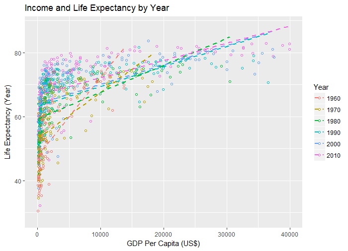

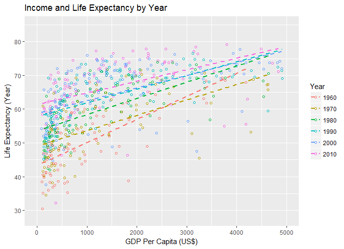

#### Life Expectancy vs Total Health Spending / Government Health Spending

The plots show that the higher the total and government health spending, the longer people can live. However, people’s lives seem to be shorter in the most recent 10 years with the same amount of health spending.

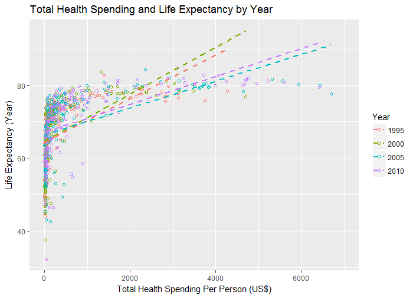

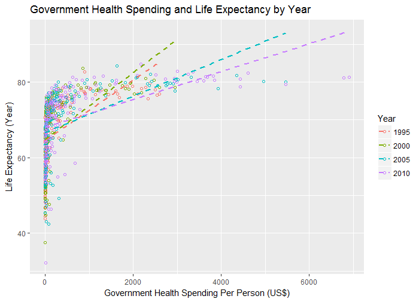

#### Life Expectancy vs Health Spending - Spending Between US$0 and US$2,000

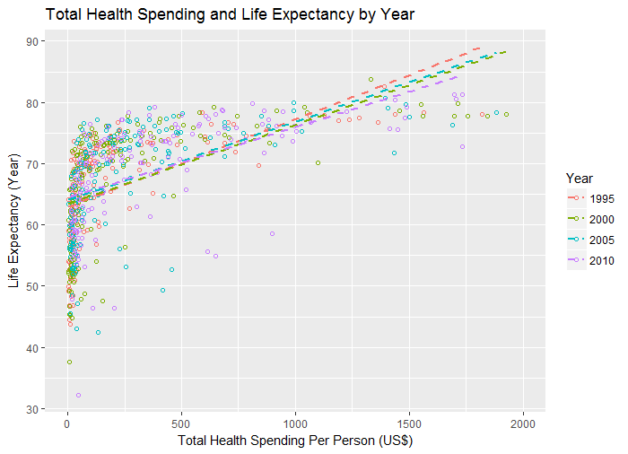

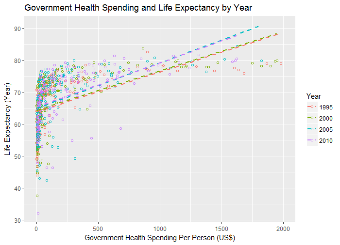

#### Life Expectancy vs Health Spending - Spending Between US$0 and US$500

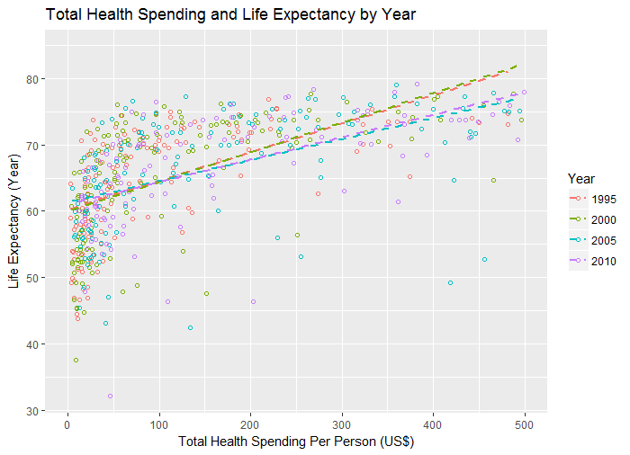

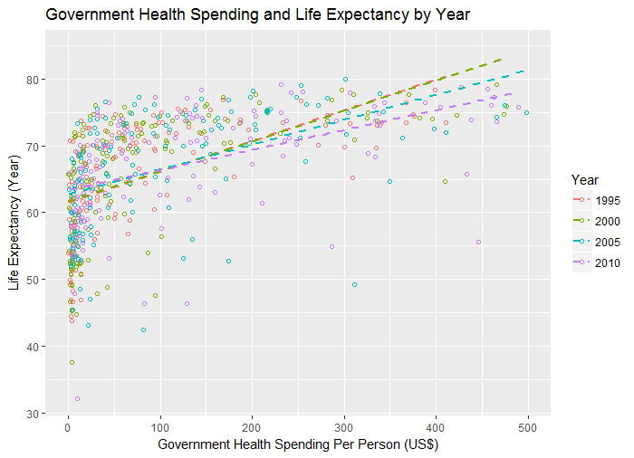

#### Life Expectancy vs Health Spending - Spending Between US$0 and US$100

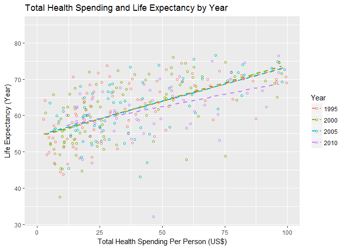

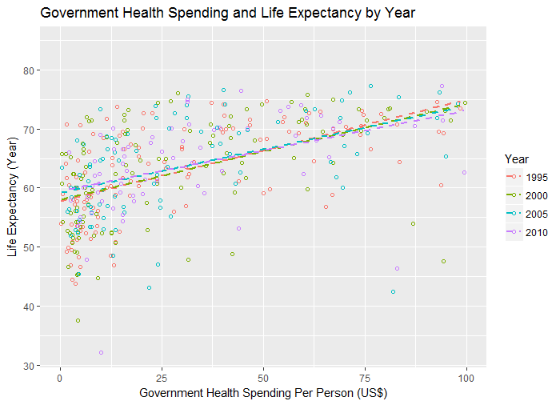

#### Life Expectancy vs Breast Cancer Deaths

The plot shows the slight increase in the year of life when the number of breast cancer deaths goes up. It possibly shows that breast cancer death itself does not closely related to the general life expectancy in countries.

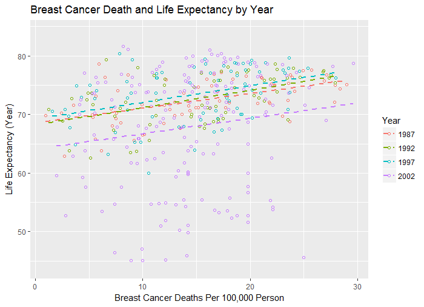

#### Life Expectancy vs Cervical Cancer Deaths

On the other hand, this plot shows the higher the cervical cancer death number, the shorter people live. The strongest negative relationship is shown in 2002.

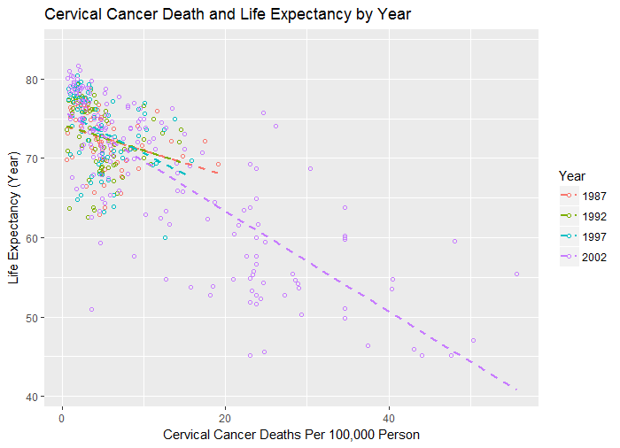

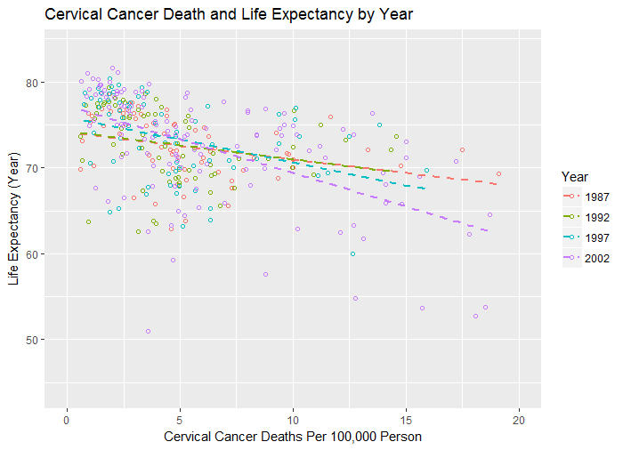

#### Life Expectancy vs Lung Cancer Deaths

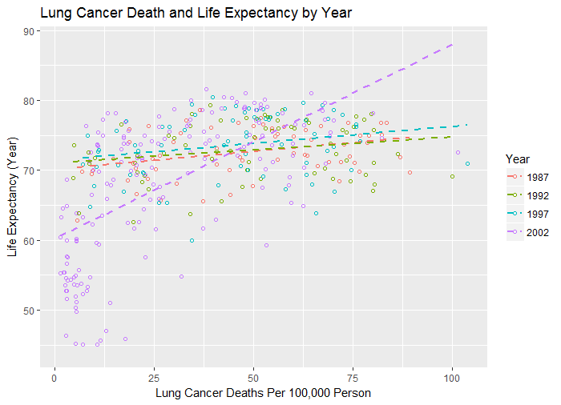

#### Life Expectancy vs Liver Cancer Deaths

The plots do not show strong relationship between life expecancy and liver cancer death from 1987 to 1997. However, in 2002, the higher the liver cancer death number, the shorter people live.

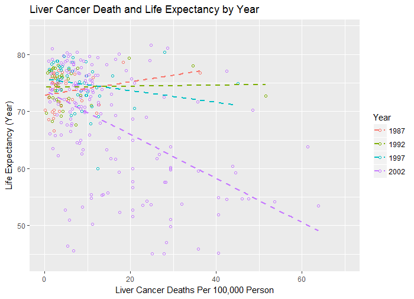

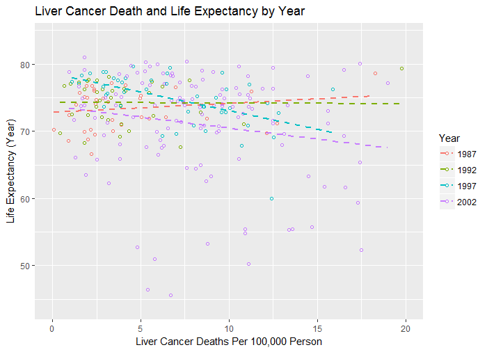

#### Life Expectancy vs Prostate Cancer Deaths

The plots do not show strong relationship between life expectancy and prostate cancer death. It possibly shows that prostate cancer death itself does not closely related to the general life expectancy in countries.

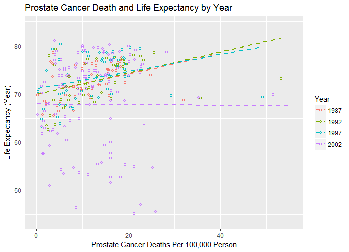

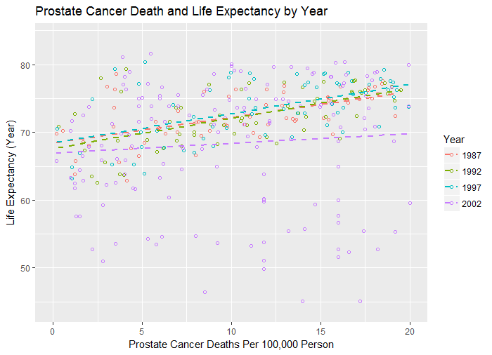

#### Life Expectancy vs Stomach Cancer Deaths

The plots show the slight negative relationship from 1987 to 1997 and slight positive relationship in 2002 between life expectancy and stomach center death. It possibly shows that stomach cancer death itself does not closely related to the general life expectancy in countries.

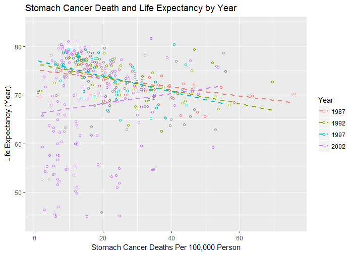

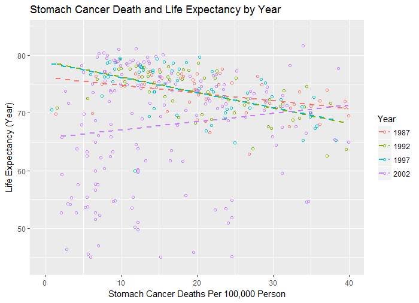